# 第2回 段を1本の式に

最小二乗法。そして、その式は本当に当たるか

# 導入

## 前回の答え

- あなたは自転車シェアの運営者。「明日何台？」に、似た日の平均で答えた
- 毎日平均と答えると外れ幅1582台 → 気温帯×年で762台

## でも、答えはガタガタの段

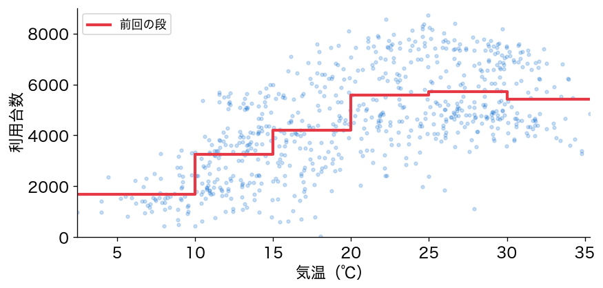

- 24.9℃と25.1℃で、答えが跳ぶ

## しかも、採点が甘かった

- 細かく分けるほど、外れ幅は縮んだ（408台まで）
- でもそれは、平均を作るのに使った日で採点していたから

## 今日の問い

段を、1本の式にしたい。その式は、まだ来ていない日にも当たるのか？

## 今日のコードの書き方

- 便利な関数の前に、1日ぶんの計算から始める
- 1日 → 731日（`for`文）→ 総当たり（`if`文）→ 式一発
- `LinearRegression`は、最後の答え合わせに使う

## この問いに、どう近づくか

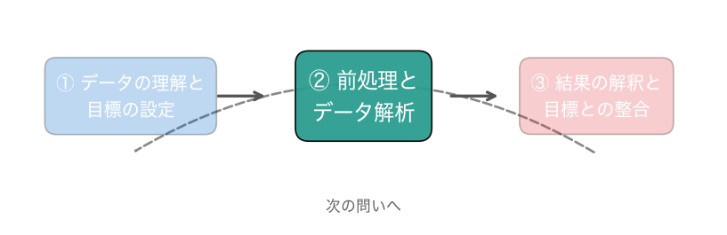

今日は、②解析が中心です。

# 0. 設定

## やってみよう：0節

- 第2回のノートを開き、ドライブにコピーする
- 0節の設定のセルを実行し、「セットアップ完了」を確かめる

動画の人は、ここで一時停止。

# 1. 列を、数の並びとして取り出す

## 式には、1日ずつの値が要る

- 直線の式は、1日の気温を入れて台数を出す
- まず、気温と台数を1日ずつ取り出せる形にする

## おさらい：列を選ぶ

```python
df['cnt']        # 台数の列だけ
```

- 表から1つの列を取り出すには、`[ ]`に列名を入れる

## お手本：列を配列にする

```python
x = df['temp'].values     # 気温（731日ぶん）
y = df['cnt'].values      # 台数（731日ぶん）
print(len(x))             # いくつ並んでいるか
print(x[0])               # 1日目の気温
print(y[0])               # 1日目の台数
```

- 役割：気温と台数を、数の並び（配列）として取り出す

## 配列は、番号で取り出す

```python
print(x[0])               # 1日目の気温
print(y[0])               # 1日目の台数
```

- `.values`を付けると、列がnumpyの配列になる
- `x[0]`のように番号で1つずつ取り出せる。番号は0から数える

## 変えてみる：2日目を見る

```python
print(x[1])               # 2日目の気温
print(y[1])               # 2日目の台数
```

- `[0]`を`[1]`に変えるだけ

## やってみよう：1節

- 1節のお手本と「変えてみる」のセルを実行する
- 1日目の台数は何台か？

動画の人は、ここで一時停止。

## 答え合わせ：1日目は985台

```
731
0.344167
985
```

- 731個の数が並ぶ。1日目は気温0.344（約14.1℃）、台数985台

# 2. 1日目を、直線で予測すると？

## 1日目は985台。直線で当てると？

- 1節で、1日目の気温0.344と台数985台を取り出した
- この1日を、直線の式で予測してみる

## 段の代わりに、直線を

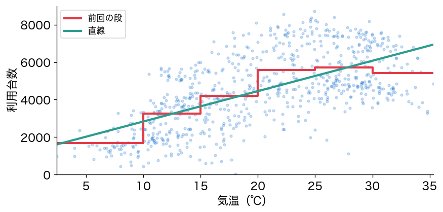

- 段の代わりに、1本の直線で答えたい

## 直線の式

- 台数 ≈ a × temp + b（tempは、気温を0〜1に縮めた値）
- a（傾き）：tempが1増えると、台数がいくら増えるか
- b（切片）：tempが0のときの台数

## tempの1は、約41℃

- temp ＝ 気温（℃）÷ 41。tempが1増えるのは、気温が約41℃上がること
- だから1℃あたりの増え方は、a ÷ 41
- 図の横軸は℃。a=6600の直線なら、1℃で約160台ずつ上がる

## 直線は、無数に引ける

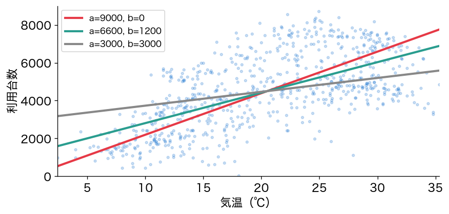

- aとbの組み合わせは、無数にある（aはtempに掛ける数）

## どれが「良い直線」？

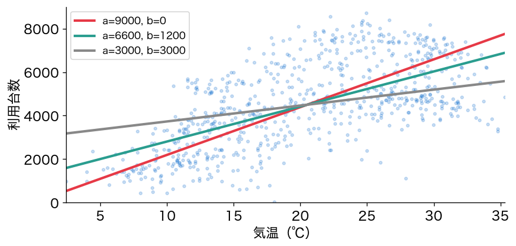

- 良さを測る物差しが要る。まず、1日目だけで考える

## お手本：1日目の予測と外れ

```python
a = 9000
b = 0
pred = a * x[0] + b       # 1日目の予測
print(pred)
err = y[0] - pred         # 外れ（実際 − 予測）
print(err)
print(err ** 2)           # 外れの二乗
```

- 役割：a=9000・b=0の直線で1日目を予測し、外れを出す

## 外れ ＝ 残差

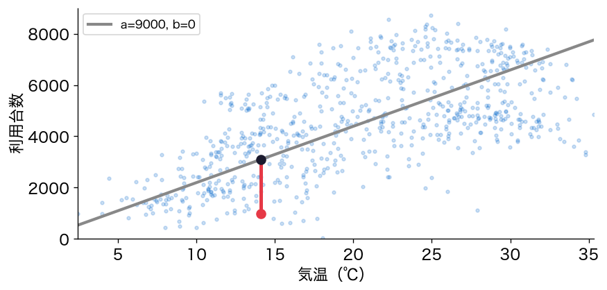

- 赤い縦線が、実際（赤い点）と予測（黒い点）のずれ。これを残差と呼ぶ

## なぜ、二乗するのか

- 外れは、多すぎても（マイナス）少なすぎても（プラス）困る
- そのまま足すと、プラスとマイナスが打ち消し合う
- 二乗すれば、どちら向きの外れもプラスの大きさになる

## 二乗の、もう1つの良さ

- 二乗の和は、aやbを動かすとなめらかな谷の形になる（4節）
- なめらかな谷なので、谷底を式一発で求められる（5節）
- 大きく外れた日ほど、二乗で重く数えられる

## TODO①：2日目と3日目も

```python
# TODO: 上のセルをコピーして、[0] を [1]（2日目）と
#       [2]（3日目）に変えて表示する
...
```

- お手本の`[0]`を、`[1]`と`[2]`に変えるだけ

## やってみよう：2節とTODO①

- 2節のお手本のセルを実行する
- TODO①：2日目と3日目の、予測・外れ・外れの二乗を出す

動画の人は、ここで一時停止。

## 答え合わせ：1日目の外れ

```
3097.503
-2112.503
4462668.925009001
```

- 予測 約3098台、実際985台。外れは −2112.5台、二乗は約446万

## 答え合わせ：TODO①

```
3271.302 -2470.302 6102391.9712040005
1767.276 -418.27600000000007 174954.81217600006
```

- 2日目の外れは −2470.3、3日目は −418.3

## 731日、同じことを書く？

- 1日ずつ書くのは、3日で大変
- 731日ぶんを、繰り返しで書きたい

# 3. 731日ぶんを、足し上げる

## 二乗和を、物差しにする

- 外れの二乗を、全日で足した値（二乗和）で直線を比べる
- 二乗和が小さいほど、よく当たる直線

## お手本：for文で足し上げる

```python
total = 0
for i in range(len(x)):
    pred = a * x[i] + b                  # その日の予測
    total = total + (y[i] - pred) ** 2   # 外れの二乗を足す
print(total)
```

- 役割：731日ぶんの外れの二乗を、1日ずつ足し上げる

## for文の読み方

```python
for i in range(len(x)):
    pred = a * x[i] + b                  # その日の予測
```

- `i`を0, 1, 2, …, 730と変えながら、下の行を繰り返す
- 字下げ（行の頭のすきま）が、繰り返す範囲の目印

## total = total + …

```python
total = 0
for i in range(len(x)):
    pred = a * x[i] + b                  # その日の予測
    total = total + (y[i] - pred) ** 2   # 外れの二乗を足す
```

- 「いまの合計に足して、合計を更新する」という意味
- 最初に`total = 0`で、合計を空にしておく

## 変えてみる：numpyで、まとめて

```python
residual = y - (a * x + b)       # 731日ぶんの外れを、まとめて
print(residual[:3])              # 最初の3日ぶん
print((residual ** 2).sum())     # 二乗して、全部足す
```

- numpyの配列は、`for`文なしでまとめて計算できる
- `.sum()`は、全部を足すメソッド

## `[:3]`は、最初の3つ

```python
print(residual[:3])              # 最初の3日ぶん
```

- `[:3]`は、番号0・1・2の3つを取り出す（スライス）
- `[始め:終わり]`の形。始めを省くと0から。終わりの番号は含まない

## やってみよう：3節

- 3節のお手本と「変えてみる」のセルを実行する
- 2つの二乗和は、同じになるか？

動画の人は、ここで一時停止。

## 答え合わせ：二乗和は約18.0億

```
1798539709.665675
```

- a=9000・b=0の直線の二乗和は、約18.0億

## 答え合わせ：numpyと一致

```
[-2112.503 -2470.302  -418.276]
1798539709.665673
```

- 最初の3日は、2節とTODO① の値そのもの。二乗和も一致
- `for`文で書いたことを、numpyは1行でやっていた

# 4. いちばん良いaとbは？

## 二乗和が最小になるa・bは？

- 物差し（二乗和）ができた
- では、二乗和がいちばん小さい直線は？
- まずは素朴に、aをいろいろ試す

## お手本：aを100ずつ試す

```python
best_a = None
best_sse = None
for a in range(5000, 8001, 100):              # 5000, 5100, …, 8000
    s = ((y - (a * x + 1200)) ** 2).sum()     # この a の二乗和
    if best_sse is None or s < best_sse:      # 小さければ覚え直す
        best_a = a
        best_sse = s
print(best_a, best_sse)
```

- 役割：bを1200に固定し、aを100ずつ変えて、二乗和が最小のaを探す

## rangeの3つの数

```python
for a in range(5000, 5301, 100):
    print(a)          # 5000, 5100, 5200, 5300 と表示される
```

- `range(始め, 終わり, 刻み)`：始めから、刻みずつ増やす
- 終わりの数は含まない。8000まで入れたいので、8001と書く

## if文の読み方

```python
    if best_sse is None or s < best_sse:      # 小さければ覚え直す
        best_a = a
        best_sse = s
```

- 条件が成り立つときだけ、下の字下げした行を実行する
- 「これまでの最小より小さければ、覚え直す」

## Noneは「まだ空」の印

```python
best_sse = None
```

- 最初は、覚えている最小がまだない
- `best_sse is None`なら、1回目は必ず覚える

## orは「または」

```python
    if best_sse is None or s < best_sse:      # 小さければ覚え直す
```

- `A or B`は、AとBのどちらかが成り立てば、成り立つ
- 1回目は`best_sse is None`で成り立つ。2回目からは`s < best_sse`で決まる

## 変えてみる：bも動かす

```python
best = None
for a in range(5000, 8001, 100):
    for b in range(0, 2001, 100):          # b も動かす
        s = ((y - (a * x + b)) ** 2).sum()
        if best is None or s < best[2]:
            best = (a, b, s)
print(best)
```

- `for`文の中に`for`文。aとbのすべての組み合わせを試す

## bestに3つを覚える

```python
            best = (a, b, s)
```

- (a, b, 二乗和) の3つを、まとめて覚える
- `best[2]`は3つ目、つまり二乗和（番号は0から）

## TODO②：範囲を狭め、細かく

```python
# TODO: 上のセルをコピーして、a を range(6400, 6801, 10)、
#       b を range(1000, 1401, 10) にする
...
```

- 変えるのは、`range`の中の数だけ

## やってみよう：4節とTODO②

- 4節のお手本と「変えてみる」のセルを実行する
- TODO②：範囲を狭め、10ずつ試す

動画の人は、ここで一時停止。

## 答え合わせ：aだけ動かすと

```
6700 1661091384.2666712
```

- a=6700のとき、二乗和が最小

## 二乗和を図にすると？

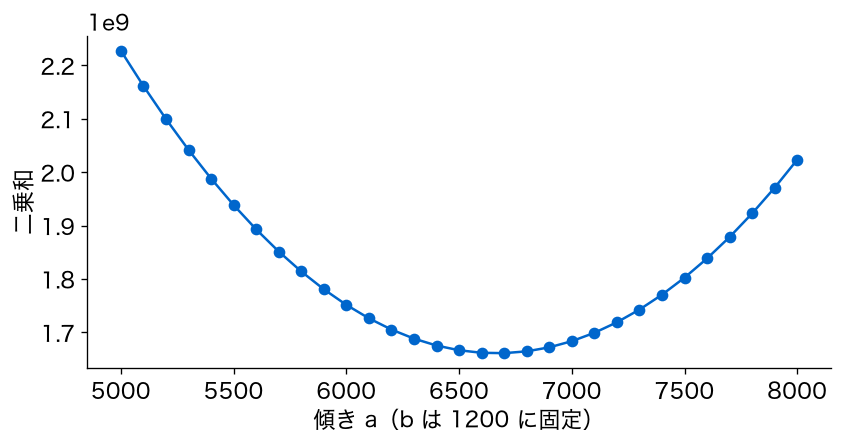

- 横がa、縦がそのaの二乗和

## 谷底は、1つだけ

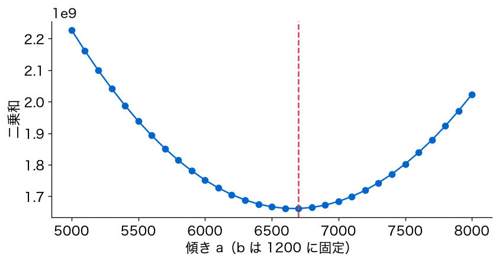

- U字の谷底が、いちばん良いa（点線の6700）

## 答え合わせ：bも動かすと

```
(6700, 1200, np.float64(1661091384.2666712))
```

- 31×21 ＝ 651通りを試して、a=6700・b=1200

## 答え合わせ：TODO②

```
(6650, 1210, np.float64(1660848919.0966713))
```

- 10ずつなら、a=6650・b=1210。二乗和は少し小さくなった

# 5. 谷底を、式一発で求める

## もっと細かくすれば？

- 1ずつ、0.1ずつ……と細かくするほど、試す数が爆発的に増える
- 本当の谷底に、一発でたどり着けないか？

## 谷底の式

$$a = \frac{\sum (x_i - \bar{x})(y_i - \bar{y})}{\sum (x_i - \bar{x})^2}, \qquad b = \bar{y} - a\,\bar{x}$$

- 二乗和をa・bで微分して0とおくと、この式が出る（$\bar{x}$・$\bar{y}$ は平均）

## これが、最小二乗法

- 外れの二乗和を最小にして、aとbを決める
- このやり方を、最小二乗法と呼ぶ

## お手本：式をfor文で計算する

```python
x_mean = x.mean()
y_mean = y.mean()
num = 0     # 分子
den = 0     # 分母
for i in range(len(x)):
    num = num + (x[i] - x_mean) * (y[i] - y_mean)
    den = den + (x[i] - x_mean) ** 2
a_best = num / den
b_best = y_mean - a_best * x_mean
print(a_best, b_best)
```

## 変えてみる：LinearRegression

```python
model_temp = LinearRegression()
model_temp.fit(df[['temp']], y)
print(model_temp.coef_[0])           # 傾き a
print(model_temp.intercept_)         # 切片 b
```

- `fit`で学ばせ、`coef_`（傾き）と`intercept_`（切片）を見る
- 列は`df[['temp']]`と二重のかっこ（表の形）で渡す

## R²：どれだけ減らせたか

- 毎日平均と答えたときの二乗和を、基準にする
- 直線で、その二乗和の何割を減らせたかがR²
- 1に近いほど、よく当たる

## 変えてみる：R²を自分で

```python
pred_line = a_best * x + b_best
sse_line = ((y - pred_line) ** 2).sum()      # 直線の二乗和
sst = ((y - y.mean()) ** 2).sum()            # 基準の二乗和
print(1 - sse_line / sst)                    # R²
print(model_temp.score(df[['temp']], y))     # 答え合わせ
```

## やってみよう：5節

- 5節のお手本と「変えてみる」のセルを実行する
- 式一発の答えは、`LinearRegression`と一致するか？

動画の人は、ここで一時停止。

## 答え合わせ：式一発の谷底

```
6640.709998548637 1214.6421190294018
```

- a=6640.71、b=1214.64。TODO② の（6650, 1210）のすぐ近く

## 答え合わせ：fit() と一致

```
6640.709998548634
1214.6421190294031
```

- `fit()`の一行の中身は、今日ここまでの計算そのもの

## 答え合わせ：R²は0.394

```
0.3937487313729241
0.3937487313729241
```

- 基準の二乗和のうち、約4割を気温の直線で減らせた

## 前回の段と比べると？

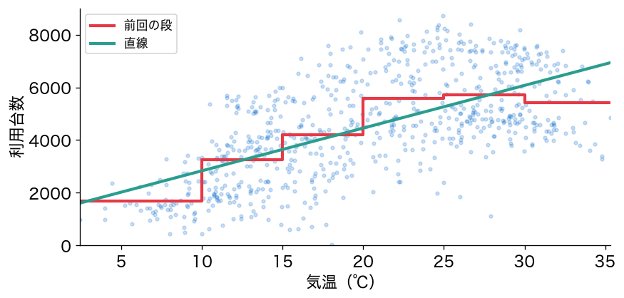

- 段のR²は0.439。直線（0.394）より、少し上

## 直線は、右端を外す

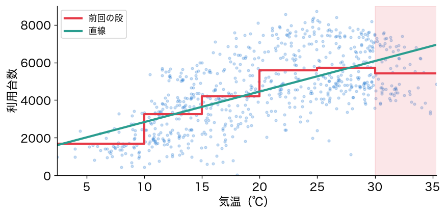

- 暑すぎると頭打ち。まっすぐな直線は、右端で多く見積もる

## それでも、直線の良さ

- 境目で跳ばない
- 1本の式で書ける。どの気温にも、なめらかに答えられる

## 手がかりを増やす

```python
model_ty = LinearRegression()
model_ty.fit(df[['temp', 'yr']], y)
print(model_ty.score(df[['temp', 'yr']], y))
```

- 列を並べるだけで、気温と年の両方を使う式（重回帰）になる
- R²は0.68まで上がる
- 各列に掛かる数（直線の傾きaにあたる数）を、係数と呼ぶ

# 6. 自己採点は、甘くないか

## ここまでのR²は、どこで測った？

- 式を作るのに使った、731日で測っていた
- 前回、作った日で採点すると甘く出ることを見た

## 訓練データと、テストデータ

- 式を作るのに使う訓練データ（過去問）
- 最後まで取っておくテストデータ（本番）
- 本番の成績が、まだ見ていない日での実力

## 前回の段で、試すと？

```
['気温帯', 'yr']
  作った日        : 766 台
  まだ見ていない日: 773 台
  答えのない日    : 0 日
  答えのある日だけ: 773 台
['mnth', 'yr', 'weathersit', 'weekday']
  作った日        : 393 台
  まだ見ていない日: 1008 台
  答えのない日    : 45 日
  答えのある日だけ: 665 台
```

- 気温帯×年の段は、作った日766台、見ていない日773台。ほぼ同じ

## 細かい段は？

```
['気温帯', 'yr']
  作った日        : 766 台
  まだ見ていない日: 773 台
  答えのない日    : 0 日
  答えのある日だけ: 773 台
['mnth', 'yr', 'weathersit', 'weekday']
  作った日        : 393 台
  まだ見ていない日: 1008 台
  答えのない日    : 45 日
  答えのある日だけ: 665 台
```

- 作った日393台 → まだ見ていない日1008台

## 45日には、答えがない

```
['気温帯', 'yr']
  作った日        : 766 台
  まだ見ていない日: 773 台
  答えのない日    : 0 日
  答えのある日だけ: 773 台
['mnth', 'yr', 'weathersit', 'weekday']
  作った日        : 393 台
  まだ見ていない日: 1008 台
  答えのない日    : 45 日
  答えのある日だけ: 665 台
```

- テスト147日のうち45日は、訓練に同じ組み合わせの日がない
- その日は答えがないので、訓練全体の平均で代用した。これが大きく外れる

## 答えのある102日でも、665台

```
['気温帯', 'yr']
  作った日        : 766 台
  まだ見ていない日: 773 台
  答えのない日    : 0 日
  答えのある日だけ: 773 台
['mnth', 'yr', 'weathersit', 'weekday']
  作った日        : 393 台
  まだ見ていない日: 1008 台
  答えのない日    : 45 日
  答えのある日だけ: 665 台
```

- 作った日の393台より、ずっと外れる

## 覚えていただけだった

- 細かい段は、作った日の台数を覚えていただけ
- 新しい組み合わせの日には、答えそのものがない

## お手本：訓練とテストに分ける

```python
cols = ['season', 'yr', 'mnth', 'holiday', 'weekday', 'workingday',
        'weathersit', 'temp', 'atemp', 'hum', 'windspeed']
X = df[cols].values
X_tr, X_te, y_tr, y_te = train_test_split(X, y, test_size=0.2,
                                          random_state=42)
print(len(X_tr), len(X_te))
```

- 役割：11本の列を手がかりに、訓練8割・テスト2割に分ける

## random_stateは、混ぜ方の番号

- `train_test_split`は、行をばらばらに混ぜてから分ける
- `random_state=42`で、混ぜ方を固定する（何度やっても同じ分け方）

## TODO③：訓練とテストのR²

```python
# TODO: 訓練データだけで fit し、訓練の R² とテストの R² を表示する
...
```

- `LinearRegression().fit(X_tr, y_tr)` → `score`を2回

## やってみよう：6節とTODO③

- 6節のお手本のセルを実行する
- TODO③：訓練だけで学び、訓練とテストのR²を比べる

動画の人は、ここで一時停止。

## 答え合わせ：584日と147日

```
584 147
```

- 訓練584日、テスト147日

## 答え合わせ：TODO③

```
訓練 R²  : 0.7910851850465888
テスト R²: 0.8276670090367212
```

- 訓練0.791、テスト0.828。ほぼ同じ

## ということは？

- この直線の式は、作った日を覚えすぎていない
- まだ見ていない日にも、同じくらい当たる

# 7. 式を曲げすぎると？

## 直線は覚えすぎない。曲げると？

- 6節で、直線は訓練0.791・テスト0.828。ほぼ同じだった
- 式を曲げても、テストで同じくらい当たる？

## 曲げれば、頭打ちも当たる？

- 直線は、暑い日の頭打ちを外した
- 気温の2乗・3乗……を足せば、式は曲線になる（何乗までかを次数と呼ぶ）

## 次数を上げると

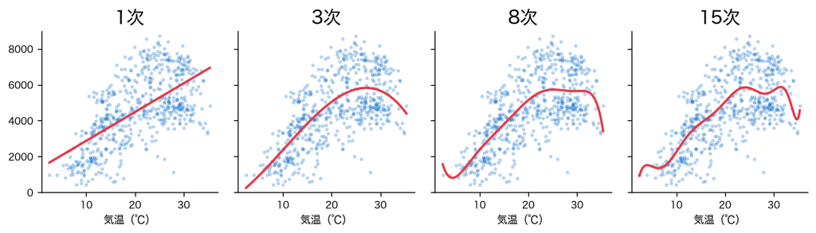

- 左から1次・3次・8次・15次。曲げるほど、点に近づく（横軸は℃）

## お手本：3次の曲線

```python
x1_tr = X_tr[:, [7]]    # 8本目の列（temp）だけ
x1_te = X_te[:, [7]]
model3 = Pipeline([('poly', PolynomialFeatures(3)),
                   ('lr', LinearRegression())])
model3.fit(x1_tr, y_tr)
print(model3.score(x1_tr, y_tr), model3.score(x1_te, y_te))
```

- `PolynomialFeatures(3)`が2乗・3乗の列を作り、`Pipeline`で直線の式につなぐ

## TODO④：次数を変えて並べる

```python
# TODO: for deg in [1, 3, 8, 15]: として、次数ごとの
#       訓練 R² とテスト R² を表示する
...
```

- お手本の`3`を`deg`に変え、`for`文の中に入れる

## やってみよう：7節とTODO④

- 7節のお手本のセルを実行する
- TODO④：次数を1・3・8・15と変えて、訓練とテストのR²を並べる

動画の人は、ここで一時停止。

## 答え合わせ：TODO④

```
1 次: 0.3881 0.4037
3 次: 0.472 0.4137
8 次: 0.4757 0.4079
15 次: 0.4812 0.4073
```

- 左が訓練のR²、右がテストのR²

## 訓練のR²は、上がり続ける

```
1 次: 0.3881 0.4037
3 次: 0.472 0.4137
8 次: 0.4757 0.4079
15 次: 0.4812 0.4073
```

- 0.388 → 0.472 → 0.476 → 0.481。曲げるほど、訓練には当たる

## テストのR²は？

```
1 次: 0.3881 0.4037
3 次: 0.472 0.4137
8 次: 0.4757 0.4079
15 次: 0.4812 0.4073
```

- 0.404 → 0.414 → 0.408 → 0.407。曲げても、ほぼ横ばい

## 584日あると、曲げても崩れない

- 訓練が584日あると、曲線は1日1日の偶然の揺れに振り回されにくい
- だから曲げすぎても、テストのR²はほとんど下がらない
- では、データが少なかったら？

## データが20日しかなかったら？

- 訓練を、584日から20日に減らしてみる
- テストは、同じ147日のまま

## 変えてみる：20日だけで学ぶ

```python
x20 = x1_tr[:20]     # 訓練の最初の20日だけ
y20 = y_tr[:20]
for deg in [1, 3, 8]:
    m = Pipeline([('poly', PolynomialFeatures(deg)),
                  ('lr', LinearRegression())])
    m.fit(x20, y20)
    print(deg, '次:', round(m.score(x20, y20), 3),
          round(m.score(x1_te, y_te), 3))
```

- `[:20]`で、訓練の最初の20日を取り出す。1・3・8次で、訓練とテストのR²

## やってみよう：20日の例

- 「変えてみる：20日だけで学ぶ」のセルと、その下の図のセルを実行する
- 訓練のR²とテストのR²は、どう動くか？

動画の人は、ここで一時停止。

## 答え合わせ：訓練は上がる

```
1 次: 0.228 0.362
3 次: 0.444 -0.288
8 次: 0.499 -28.353
```

- 左の訓練のR²は0.228 → 0.444 → 0.499。曲げるほど上がる

## テストは、マイナスに

```
1 次: 0.228 0.362
3 次: 0.444 -0.288
8 次: 0.499 -28.353
```

- 右のテストのR²は0.362 → −0.288 → −28.353
- マイナスは、毎日平均と答えるより悪いということ

## 8次の曲線は、点のない所で暴れる

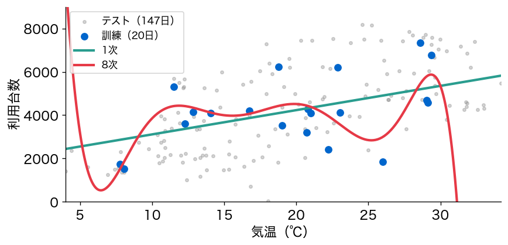

- 青い20日に合わせて曲がり、20日の外（8℃未満・29℃超）で大きく外れる

## これが、過学習

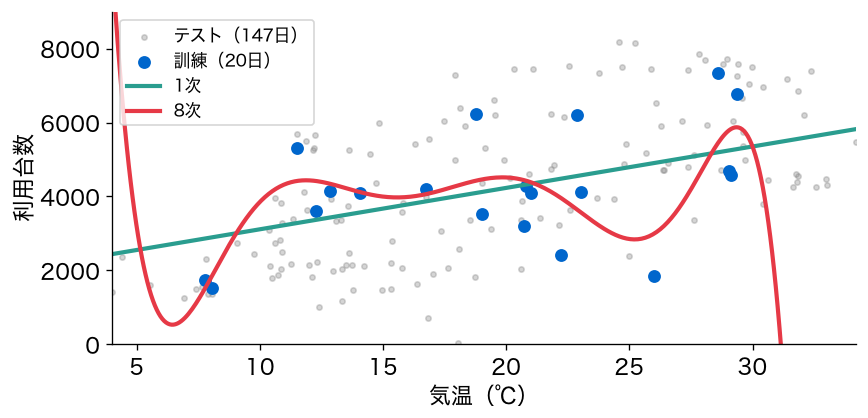

- 曲げすぎた式は、訓練データの偶然の揺れまで覚える
- データが少ないほど、はっきり出る

# 8. 分け方の運を、ならす

## 0.828は、1回の分け方

- 6節のテストのR²は、1回の分け方で出た値
- 分け方が変われば、値も変わる

## 交差検証

- データを5つに分ける
- 1つをテスト、残り4つを訓練に。これを5回、テストを入れ替えてくり返す
- 5つのR²の平均とばらつきを見る

## お手本：5分割の交差検証

```python
kf = KFold(n_splits=5, shuffle=True, random_state=42)
scores = cross_val_score(LinearRegression(), X, y, cv=kf,
                         scoring='r2')
print(scores.round(3))
print(scores.mean().round(3), scores.std().round(3))
```

- 役割：5通りの分け方で学んでテストし、R²を5つ出す

## やってみよう：8節

- 8節のお手本のセルを実行する
- 5つのR²は、どれくらい動くか？

動画の人は、ここで一時停止。

## 答え合わせ：5つのR²

```
[0.828 0.746 0.813 0.722 0.808]
0.783 0.042
```

- 0.72〜0.83と、分け方で0.1ほど動く

## 平均0.78、ばらつき ±0.04

```
[0.828 0.746 0.813 0.722 0.808]
0.783 0.042
```

- 1回の0.83は、運の良い分け方だったかもしれない

## 正直な実力の言い方

実力は「R²はおよそ0.78、±0.04くらい」。1回の値で言い切らない。

# 9. 明日は何台？

## 実力は測れた。では、明日は何台？

- 交差検証で、R²はおよそ0.78、±0.04くらいと分かった
- 同じく、まだ見ていない日で外れ幅を測り、明日を予測する

## お手本：気温と年で測る

```python
Xty = df[['temp', 'yr']].values
a_tr, a_te, b_tr, b_te = train_test_split(Xty, y, test_size=0.2,
                                          random_state=42)
model_ty = LinearRegression().fit(a_tr, b_tr)
err_tr = np.abs(b_tr - model_ty.predict(a_tr)).mean()
err_te = np.abs(b_te - model_ty.predict(a_te)).mean()
print('作った日の外れ幅  :', round(err_tr), '台')
print('まだ見ていない日  :', round(err_te), '台')
pred_t = model_ty.predict([[27 / 41, 1]])[0]     # 27℃・2年目
print('明日（27℃・2年目）:', round(pred_t), '台')
```

- 作った日と、まだ見ていない日の外れ幅。そして明日（27℃・2年目）の予測

## 答え：およそ6600台

```
作った日の外れ幅  : 859 台
まだ見ていない日  : 837 台
明日（27℃・2年目）: 6565 台
```

およそ6600台。まだ見ていない日での外れ幅は、平均840台くらい。

## 前回の7200台より、低いのは？

- 前回の答えは、およそ7200台。今日は、およそ6600台
- なぜ、今日のほうが低いのか？

## 晴れの日に絞っていない

- 前回は、25〜30℃・2年目の晴れの日（54日）だけの平均
- 今日の式は、天気を入れていない。晴れも雨も混ぜた見積もり
- 答えが下がった主な理由は、晴れの日に絞っていないこと

## 外れ幅は、同じテストで比べる

- 前回の「500台前後」は、晴れの54日の中で、作った日で測った外れ幅
- 同じテスト147日なら、気温帯×年の段773台、今日の直線837台
- 直線は境目で跳ばないが、頭打ちを外すぶん、少し外れる

## まだ言えないこと①：データの汚れ

- 今日のデータは、欠けた値も文字の列もない、きれいなデータ
- 実務のデータは、そうはいかない

## まだ言えないこと②：物差し

- R²も二乗和を使うので、大外れを重く見ている
- 外れ幅の平均は、どの外れも同じ重さ。どちらで測るかは場面しだい

## まだ言えないこと③：係数の読み方

- 年の係数 約2083は「2年目は、同じ気温でも2083台多い」と読めるのか？

# まとめ

## 今日の歩み

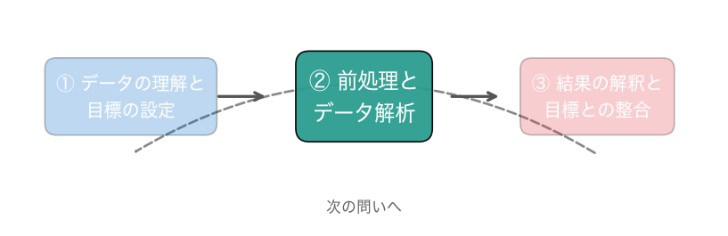

1日の計算 → 731日 → 総当たり → 式一発 → 分けて測る → 曲げすぎ → 交差検証

## 今日の要点

- 直線の良さは二乗和で測る。二乗和を最小にするのが最小二乗法
- `for`文で1日ずつ足した値と、numpyのまとめて計算は一致する
- 作るのに使ったデータの成績は甘い。訓練とテストに分けて測る
- 曲げすぎると過学習。データが少ないほど、はっきり出る
- 交差検証で、分け方の運をならす
- Python：配列（`.values`・`x[0]`）、`for`文、`if`文

## 課題の出し方

- ノートの最後の「課題（提出）」に取り組む
- 応用②の答えと応用③の文章を、LACSに入力して提出（＝出席。期限なし）
- AIを使ってもよい。何を聞いて、どう直したかを1行書く

## 次回予告：データを整える

- 場面は、民泊の値付け
- 極端な値・欠けた値・文字の列・ばらばらの目盛りを、一つずつ整える

## 次回の問い

自分の部屋に、1泊いくらの値段を付ければいいか？

## このあと：課題へ

ノートの「課題（提出）」へ。分け方を5通りに変えて、テストのR²の揺れを測ります。